# Lab Assignment 2

Name: **Rafiqul Islam** ; student id : **12123971**

## Task -1 Dimensionality Reduction, Principal Component Analysis

## a)

```python
import numpy as np
import pandas as pd
import sklearn

import matplotlib.pyplot as plt

from sklearn.preprocessing import StandardScaler
from sklearn.decomposition import PCA
from sklearn.utils.extmath import svd_flip

from numpy.linalg import svd
```

#### external sources:

1) https://numpy.org/doc/stable/reference/generated/numpy.linalg.svd.html  
2) https://stackoverflow.com/questions/44765682/in-sklearn-decomposition-pca-why-are-components-negative

```python
#read data form csv file using pandas
df = pd.read_csv (r'seeds.csv')
x = df.copy()
# list of column names
y = df.columns.values.tolist()
x.head()
```

|  | Area | Perimeter | Compactness | Kernel.Length | Kernel.Width | Asymmetry.Coeff | Kernel.Groove | Type |
| --- | --- | --- | --- | --- | --- | --- | --- | --- |
| 0 | 15.26 | 14.84 | 0.8710 | 5.763 | 3.312 | 2.221 | 5.220 | 1 |
| 1 | 14.88 | 14.57 | 0.8811 | 5.554 | 3.333 | 1.018 | 4.956 | 1 |
| 2 | 14.29 | 14.09 | 0.9050 | 5.291 | 3.337 | 2.699 | 4.825 | 1 |
| 3 | 13.84 | 13.94 | 0.8955 | 5.324 | 3.379 | 2.259 | 4.805 | 1 |
| 4 | 16.14 | 14.99 | 0.9034 | 5.658 | 3.562 | 1.355 | 5.175 | 1 |

```python
# scaling data by using standard scaler
std_scaler = StandardScaler()
x_scaled = std_scaler.fit_transform(x)
# x_scaled
```

```python
#SVD part start-----------------------------------------------------------
#getting U, S, V matrix by using numpy svd function
U, S, V = svd(x_scaled, full_matrices=False)
print("matrix U = ")
print(U.shape)
print("matrix S = ")
print(S.shape)
print("matrix V = ")
print(V.shape)

# calculate explained variance ratio from S matrix
var_explained_svd = np.round(S**2/np.sum(S**2), decimals=3)
var_explained_svd
```

```
matrix U =
(199, 8)
matrix S =
(8,)
matrix V =
(8, 8)
```

```
array([0.648, 0.214, 0.085, 0.045, 0.006, 0.002, 0.001, 0.   ])
```

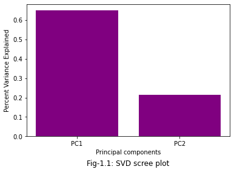

```python
# plotting explained_variance_ratio for PC1 and PC2 using SVD
svd_labels = ['PC' + str(x) for x in range(1, 3)]
plt.bar(x=list(range(1,3)),
        height=var_explained_svd[0:2],
        tick_label = svd_labels,
        color="purple")

plt.xlabel('Principal components')
plt.ylabel('Percent Variance Explained')
plt.title('Fig-1.1: SVD scree plot',  y = -0.25)
plt.show()
#SVD part end-----------------------------------------------------------
```

```python
#Sklearn PCA part start-----------------------------------------------------------

pca = PCA(n_components=2)
x_pca = pca.fit_transform(x_scaled)
var_explained_pca = np.round(pca.explained_variance_ratio_,
                             decimals=3)
var_explained_pca
```

```
array([0.648, 0.214])
```

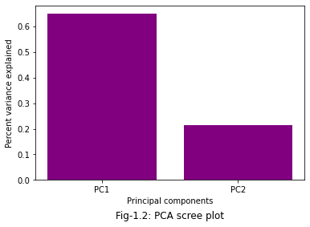

```python
# plotting explained_variance_ratio for PC1 and PC2 using Sklearn PCA
pca_labels = ['PC' + str(x) for x in range(1, len(var_explained_pca)+1)]
plt.bar(x=range(1, len(var_explained_pca)+1),
        height=var_explained_pca,
        tick_label = pca_labels,
        color="purple")
plt.ylabel('Percent variance explained')
plt.xlabel('Principal components')
plt.title('Fig-1.2: PCA scree plot',  y = -0.25)
plt.show()
#Sklearn PCA part end-----------------------------------------------------------
```

Here Fig-1.1 contains the value of explained variance ratio from SVD and Fig-1.2 contains the value from Sklearn PCA version of code. From Fig-1.1 and Fig-1.2 we can see that Percent variance explained value for PC1 and PC2 are exactly same for SVD and Sklearn PCA version.

## b)

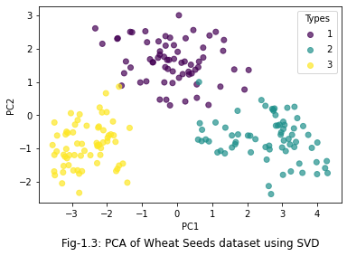

```python
# plotting first two PC data using SVD

# flip eigenvectors' sign to enforce deterministic output
U, V = svd_flip(U, V)

# calculating first 2 PC from SVD
pc1 = U[:,0]*S[0]
pc2 = U[:,1]*S[1]
x_pca_from_svd = np.array([pc1, pc2])

types = df.Type
points = plt.scatter(x_pca_from_svd[0],
                     x_pca_from_svd[1],
                     c = types,
                     alpha=0.7)
plt.xlabel('PC1')
plt.ylabel('PC2')
plt.title("Fig-1.3: PCA of Wheat Seeds dataset using SVD",  y = -0.25)
plt.legend(*points.legend_elements(), title="Types")
plt.show()
```

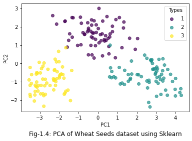

```python
# plotting first two PC data using Sklearn PCA
types = df.Type
points = plt.scatter(x_pca[:,0],
                     x_pca[:,1],
                     c = types,
                     alpha=0.7)
plt.xlabel('PC1')
plt.ylabel('PC2')
plt.title("Fig-1.4: PCA of Wheat Seeds dataset using Sklearn",  y = -0.25)
plt.legend(*points.legend_elements(), title="Types")
plt.show()
```

Fig-1.3 showing data from SVD version and Fig-1.4 showing Sklearn version of Principal Componant Analysis. During SVD implementation the values of Principal components were negative, as a result the Figure was looked like fliped. From stackoverflow a solution was taken to resolve this problem. From Sklearn the svd_flip was used. After using svd_flip everything looks perfect. From the Fig-1.3 and Fig-1.4 that can be seen clearly that Sklearn PCA and SVD both version of data are same. They reduced the dimentation of data perfectly.

## c)

### The importance of PCA in the “curse of dimensionality” problem:

'curse of dimensionality' is a major problem in data mining in large data sets with many potential predictor variables. This expression describe the increasing difficulty in training a model when more predictor variables are added to it. In other words, the error increases with the increase in the number of features. Furthermore, because of high dimentation the algorithms are harder to design.

Principal component analysis (PCA) can solve this problem. PCA is a technique for reducing the large dimensionality of datasets to a smaller one that still contain the most important information from the large set. So without lossing much information we get the lower dimensional data, lower dimensional data is make the computations easy and faster.

## Task -2 Clustering

## a)

```python
import pandas as pd
import numpy as np

from sklearn import mixture
from sklearn.preprocessing import MinMaxScaler
from sklearn.cluster import KMeans
from sklearn.cluster import DBSCAN
from sklearn.neighbors import NearestNeighbors
from sklearn.cluster import AgglomerativeClustering

from sklearn.metrics import silhouette_score
from sklearn.metrics.cluster import normalized_mutual_info_score

# import scipy.cluster.hierarchy as shc

import matplotlib.pyplot as plt
%matplotlib inline
```

```python
#read data(dataset1) form csv file using pandas and store into df1
df1 = pd.read_csv (r'dataset1_noCluster7.csv')

#scaling data
scaler = MinMaxScaler()
df1['Y'] = scaler.fit_transform(df1[["Y"]])
df1['X'] = scaler.fit_transform(df1[["X"]])
df1.head()
```

|  | X | Y | label |
| --- | --- | --- | --- |
| 0 | 0.367470 | 0.981618 | 2 |
| 1 | 0.347892 | 0.941176 | 2 |
| 2 | 0.334337 | 0.970588 | 2 |
| 3 | 0.325301 | 0.987132 | 2 |
| 4 | 0.313253 | 0.959559 | 2 |

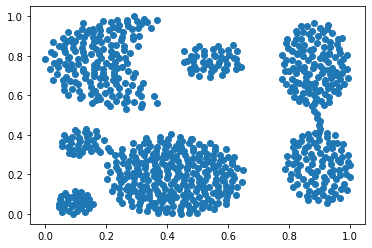

```python
#plot data(dataset1) using scatter plot
plt.scatter(df1['X'], df1['Y'])
plt.show()
```

```python
#read data(dataset2) form csv file using pandas and store into df2
df2 = pd.read_csv (r'dataset2_noCluster6.csv')
#scaling data
scaler = MinMaxScaler()
df2['Y'] = scaler.fit_transform(df2[["Y"]])
df2['X'] = scaler.fit_transform(df2[["X"]])
df2.head()
```

|  | X | Y | label |
| --- | --- | --- | --- |
| 0 | 0.548252 | 0.964706 | 1 |
| 1 | 0.633566 | 0.964706 | 1 |
| 2 | 0.682517 | 0.902941 | 1 |
| 3 | 0.574825 | 0.888235 | 1 |
| 4 | 0.636364 | 0.835294 | 1 |

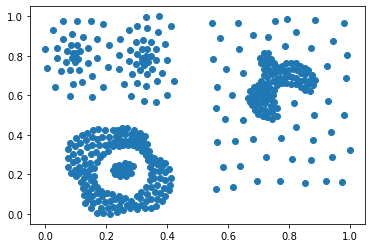

```python
#plot data(dataset2) using scatter plot
plt.scatter(df2['X'], df2['Y'])
plt.show()
```

```python
#read data(dataset3) form csv file using pandas and store into df3
df3 = pd.read_csv (r'dataset3_noCluster2.csv')
#scaling data
scaler = MinMaxScaler()
df3['Y'] = scaler.fit_transform(df3[["Y"]])
df3['X'] = scaler.fit_transform(df3[["X"]])
df3.head()
```

|  | X | Y | C |
| --- | --- | --- | --- |
| 0 | 0.462567 | 0.827002 | 1 |
| 1 | 0.417728 | 0.287905 | 2 |
| 2 | 0.372799 | 0.368506 | 2 |
| 3 | 0.171456 | 0.795269 | 1 |
| 4 | 0.943495 | 0.267225 | 2 |

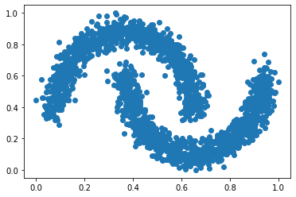

```python
#plot data(dataset3) using scatter plot
plt.scatter(df3['X'], df3['Y'])
plt.show()
```

```python
#read data(dataset4) form csv file using pandas and store into df4
df4 = pd.read_csv (r'dataset4_noCluster2.csv')
#scaling data
scaler = MinMaxScaler()
df4['Y'] = scaler.fit_transform(df4[["Y"]])
df4['X'] = scaler.fit_transform(df4[["X"]])
df4.head()
```

|  | X | Y | C |
| --- | --- | --- | --- |
| 0 | 0.787066 | 0.443775 | 1 |
| 1 | 0.747541 | 0.356564 | 1 |
| 2 | 0.618671 | 0.356595 | 1 |
| 3 | 0.893269 | 0.350083 | 1 |
| 4 | 0.747625 | 0.670901 | 1 |

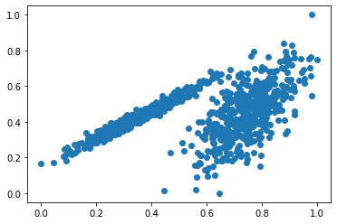

```python
#plot data(dataset3) using scatter plot
plt.scatter(df4['X'], df4['Y'])
plt.show()
```

## b)

```python
#defining helper functions here=================================================================================================

#plot function------------------------------------------------------------------------------------------------------------------
def plot_data(df, title):

    #get unique clusters labels from dataframe's cluster column, we stored cluster values when we run the algorithoms
    clusters_unique = df.cluster.unique()
    clusters_unique.sort()

    #declare a dictionary to dynamically keeps different clusters data
    c_dic = {}
    for index in clusters_unique:

        #update dictionary with different cluster's data
        #sample dictionary data shape
        #ex: c_dic = {'c1': data, 'c2': data, ....}
        c_dic['c'+str(index)] = df[df.cluster==index]
        #plot different cluster's data
        plt.scatter(c_dic['c'+str(index)].X,
                    c_dic['c'+str(index)].Y,
                    alpha=0.7,
                    label= "noise" if index == -1 else 'c'+str(index))
    plt.xlabel('X')
    plt.ylabel('Y')
    plt.title(title)
    plt.legend(bbox_to_anchor=(1.05, 1), loc=2, borderaxespad=0.0)
    plt.show()



#calculate score for cluster function-------------------------------------------------------------------------------------------
def getScore(df, y_pred):

    true_labels = []

    #reading true labels from dataFrame that already given,
    #2 dataset contains true labels in 'label' column and other 2 contains in 'C' column
    if 'label' in df.columns:
        true_labels = df['label']
    else:
        true_labels = df['C']

    #get silhouette score
    sltt_score = silhouette_score(df[['X','Y']],
                                  y_pred)

    #get Normalized mutual info score
    nmi_score = normalized_mutual_info_score(true_labels,
                                             y_pred)

    #print("Silhouette score--------------------->{}".format(sltt_score))
    #print("Normalized mutual info score--------->{}".format(nmi_score))

    return [sltt_score, nmi_score]



#K-Means function---------------------------------------------------------------------------------------------------------------
def k_means(df=df1):

    #finding optimal K value using 'silhouette scores' and 'normalized mutual info score'--------------------------
    all_scores = []
    rng = range(2,11)
    optimal_clusters = 1
    max_score = 0
    for k in rng:
        #apply k-means form sklearn for k =  2,3,4,5....10
        km = KMeans(n_clusters=k)
        y_pred = km.fit_predict(df[['X','Y']])

        #get silhouette and Normalized mutual info score for different clusters, ex: 2,3,4,5....10
        single_scores = getScore(df, y_pred)
        all_scores.append(single_scores)

        #if max score found from silhouette scores then we will update it in max_score
        if single_scores[0] > max_score:
            max_score = single_scores[0]
            optimal_clusters = k

        #if max score found from normalized mutual info score then we will update it in max_score
        if single_scores[1] > max_score:
            max_score = single_scores[1]
            optimal_clusters = k

    all_scores = np.array(all_scores)

    #Plot scores curves, that score close to 1 is better.
    #we take heighst score's corrosponding cluster number value form x-axis as our optimal K value
    plt.ylim(0, 1)
    plt.xlabel('Number of Clusters')
    plt.ylabel('Scores')
    plt.title('select optimal k value from K-Means')
    plt.plot(rng, all_scores[:,0], linestyle='--', marker='o', color='g', label='silhouette scores')
    plt.plot(rng, all_scores[:,1], linestyle='--', marker='o', color='b', label='normalized mutual info score')
    plt.axvline(x=optimal_clusters, color='r', linestyle='--')
    plt.legend(bbox_to_anchor=(1.05, 1), loc=2, borderaxespad=0.0)
    plt.show()
    print("Optimal K value for this dataset(K-Means): {}".format(optimal_clusters))


    #apply k-means form sklearn.cluster with optimal k value we have calculated------------------------------------
    km = KMeans(n_clusters=optimal_clusters)
    y_pred = km.fit_predict(df[['X','Y']])

    #add new column as 'cluster' in data frame with predieted cluster values
    df['cluster']=y_pred
    # print(km.cluster_centers_)

    #get silhouette and Normalized mutual info score
    score_list = getScore(df, y_pred)
    score_list.append('k-means')

    ##Elbow Plot to visuallize the errors for different k, and select optimal k value from plot
    #sse = []
    #k_rng = range(1,10)
    #for k in k_rng:
    #    km1 = KMeans(n_clusters=k)
    #    km1.fit(df1[['X','Y']])
    #    sse.append(km1.inertia_)

    #plt.xlabel('K')
    #plt.ylabel('Sum of squared error')
    #plt.title('Elbow Plot, select best k value from plot')
    #plt.plot(k_rng,sse)
    #plt.show()


    #call custom plot function to plot clustered data--------------------------------------------------------------
    plot_data(df, 'K-means Clustering')

    return score_list


#DBSCAN function----------------------------------------------------------------------------------------------------------------
def db_scan(eps=0.5, min_samples=5, df=df1):

    #finding best epsilon value for dbscan algorithm---------------------------------------------------------------
    nneigh = NearestNeighbors(n_neighbors=2)
    nbrs = nneigh.fit(df[['X','Y']])
    distances, indices = nbrs.kneighbors(df[['X','Y']])

    # Plotting K-distance Graph
    distances = np.sort(distances, axis=0)
    distances = distances[:,1]
    plt.plot(distances)
    plt.title('K-distance Graph')
    plt.xlabel('Data Points sorted by distance')
    plt.ylabel('Epsilon')
    plt.show()


    #apply DBSCAN form sklearn.cluster------------------------------------------------------------------------------
    dbscan = DBSCAN(eps=eps,
                    min_samples=min_samples,
                    n_jobs=-1)
    y_pred = dbscan.fit_predict(df[['X','Y']])

    #add new column as 'cluster' in data frame with predieted cluster values
    df['cluster']=y_pred
```

```python
    #get silhouette and Normalized mutual info score
    score_list = getScore(df, y_pred)
    score_list.append('DBSCAN')

    #call custom plot function to plot clustered data
    plot_data(df, 'DBSCAN Clustering')

    return score_list


#Expectation maximizatin with gussian function----------------------------------------------------------------------------------
def expectation_maximization(covariance_type='tied', n_init=10, init_params='random', df=df1):

    #finding optimal n_components value using 'silhouette scores' and 'normalized mutual info score'----------------
    all_scores = []
    rng = range(2,11)
    optimal_clusters = 1
    max_score = 0
    for k in rng:
        #apply BayesianGaussianMixture form sklearn for n_components =  2,3,4,5....10
        gmm = mixture.BayesianGaussianMixture(n_components=k,
                                              covariance_type=covariance_type,
                                              n_init=n_init,
                                              max_iter=120,
                                              init_params=init_params)
        y_pred = gmm.fit_predict(df[['X','Y']])

        #get silhouette and Normalized mutual info score for different clusters, ex: 2,3,4,5....10
        single_scores = getScore(df, y_pred)
        all_scores.append(single_scores)

        #if max score found from silhouette scores then we will update it in max_score
        if single_scores[0] > max_score:
            max_score = single_scores[0]
            optimal_clusters = k

        #if max score found from normalized mutual info score then we will update it in max_score
        if single_scores[1] > max_score:
            max_score = single_scores[1]
            optimal_clusters = k

    all_scores = np.array(all_scores)

    #Plot scores curves, that score close to 1 is better.
    #we take heighst score's corrosponding cluster number value form x-axis as our optimal cluster value
    plt.ylim(0, 1)
    plt.xlabel('Number of Clusters')
    plt.ylabel('Scores')
    plt.title('select optimal n_components value from EM')
    plt.plot(rng, all_scores[:,0], linestyle='--', marker='o', color='g', label='silhouette scores')
    plt.plot(rng, all_scores[:,1], linestyle='--', marker='o', color='b', label='normalized mutual info score')
    plt.axvline(x=optimal_clusters, color='r', linestyle='--')
    plt.legend(bbox_to_anchor=(1.05, 1), loc=2, borderaxespad=0.0)
    plt.show()
    print("Optimal n_components value for this dataset(EM): {}".format(optimal_clusters))


    #apply BayesianGaussianMixture form sklearn with optimal n_components value we have calculated-----------------
    gmm = mixture.BayesianGaussianMixture(n_components=optimal_clusters,
                                          covariance_type=covariance_type,
                                          n_init=n_init,
                                          max_iter=120,
                                          init_params=init_params)
    y_pred = gmm.fit_predict(df[['X','Y']])
    #add new column as 'cluster' in data frame with predieted cluster values
    df['cluster']=y_pred

    #get silhouette and adjusted score
    score_list = getScore(df, y_pred)
    score_list.append('Expectation maximization')

    #call custom plot function to plot clustered data
    plot_data(df, 'Expectation maximization Clustering')

    return score_list



#Agglomerative Clustering function----------------------------------------------------------------------------------------------------------
def agglomerative_clustering(n_clusters=2,linkage="ward", df=df1):

    #finding optimal k value using 'silhouette scores' and 'normalized mutual info score'--------------------------
    all_scores = []
    rng = range(2,11)
    optimal_clusters = 1
    max_score = 0
    for k in rng:
       #apply AgglomerativeClustering form sklearn for n_clusters=2,3,4,5....10
        ac = AgglomerativeClustering(n_clusters=k,
                                     linkage=linkage)
        y_pred = ac.fit_predict(df[['X','Y']])

        #get silhouette and Normalized mutual info score for different clusters, ex: 2,3,4,5....10
        single_scores = getScore(df, y_pred)
        all_scores.append(single_scores)

        #if max score found from silhouette scores then we will update it in max_score
        if single_scores[0] > max_score:
            max_score = single_scores[0]
            optimal_clusters = k

        #if max score found from normalized mutual info score then we will update it in max_score
        if single_scores[1] > max_score:
            max_score = single_scores[1]
            optimal_clusters = k

    all_scores = np.array(all_scores)

    #Plot scores curves, that score close to 1 is better.
    #we take heighst score's corrosponding cluster number value form x-axis as our optimal cluster value
    plt.ylim(0, 1)
    plt.xlabel('Number of Clusters')
    plt.ylabel('Scores')
    plt.title('select optimal n_clusters value from Agglomerative Clustering')
    plt.plot(rng, all_scores[:,0], linestyle='--', marker='o', color='g', label='silhouette scores')
    plt.plot(rng, all_scores[:,1], linestyle='--', marker='o', color='b', label='normalized mutual info score')
    plt.axvline(x=optimal_clusters, color='r', linestyle='--')
    plt.legend(bbox_to_anchor=(1.05, 1), loc=2, borderaxespad=0.0)
    plt.show()
    print("Optimal n_clusters value for this dataset(Agglomerative Clustering): {}".format(optimal_clusters))


    #apply Agglomerative clustering form sklearn.cluster-----------------------------------------------------------
    #linkage="average"/"ward"/"complete"/"single"
    ac = AgglomerativeClustering(n_clusters=optimal_clusters,
                                 linkage=linkage)
    y_pred = ac.fit_predict(df[['X','Y']])
    #add new column as 'cluster' in data frame with predieted cluster values
    df['cluster']=y_pred

    #get silhouette and Normalized mutual info score
    score_list = getScore(df, y_pred)
    score_list.append('Agglomerative Clustering')
```

```python
    #call custom plot function to plot clustered data
    plot_data(df, 'Agglomerative Clustering')

    return score_list
```

```
The optimal epsilon value has been choosen form the k-distance Graph. We took that epsilon value when the epsilon value increasing suddendly and never decrease.

Dataset-1:
```

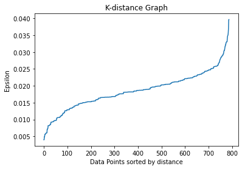

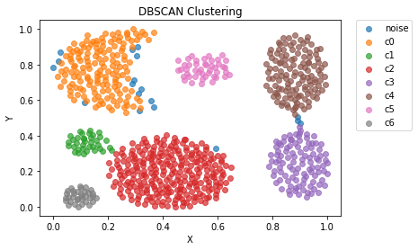

```
Dataset-2:
```

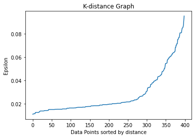

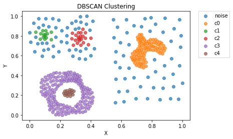

```
Dataset-3:
```

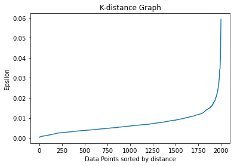

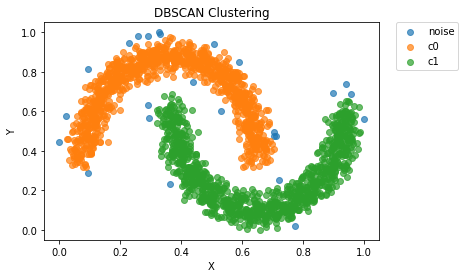

```
Dataset-4:
```

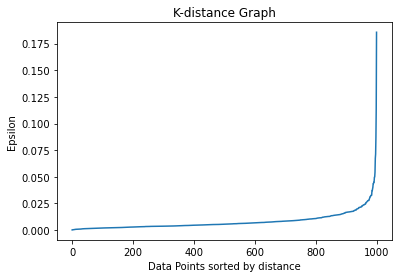

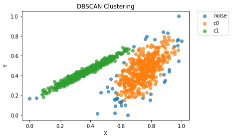

```
[0.48521514011086214, 0.8591633760766444, 'DBSCAN']
```

```python
print("The optimal epsilon value has been choosen form the k-distance Graph. We took that epsilon value when the epsilon value increasing suddendly and never decrease.\n")
# applying DBSCAN clustering algorithm for dataset1
print("Dataset-1:")
db_scan(eps=0.036, min_samples=5, df=df1)

print("Dataset-2:")
# applying DBSCAN clustering algorithm for dataset2
db_scan(eps=0.04, min_samples=5, df=df2)

print("Dataset-3:")
# applying DBSCAN clustering algorithm for dataset3
db_scan(eps=0.03, min_samples=5, df=df3)

print("Dataset-4:")
# applying DBSCAN clustering algorithm for dataset4
db_scan(eps=0.035, min_samples=5, df=df4)
```

#### Used cluster: DBSCAN

Some of the given datasets contain non-linear shapes and some of them contain noise data points. To cluster them, I tried different cluster algorithms like DBSCAN, KMeans, Expectation-Maximization (EM), and AgglomerativeClustering. In average DBSCAN performs better but in different dataset different algorithm gives best output.

#### Parameters chosen:

I used three parameters from DBSCAN. They are: *eps*, *min_samples*, *n_jobs*.

#### Reasons to choose these parameters:

*eps*: The maximum distance between two samples for one to be considered as in the neighborhood of the other. This is the most important DBSCAN parameter that needs to be properly selected for datasets and distance functions. DBSCAN will cluster the same dataset differently depending on this parameter. To select the best value for this parameter I plot the K-distance graph using the **NearestNeighbors** library. From this graph, we can see when is the data density is increasing. All we have to do to pick the best value for epsilon is to pick an epsilon value from where the epsilon is increasing instantly. In our case for the first dataset, epsilon = 0.036 and for dataset2, 3, 4 are 0.04, 0.03, 0.035.

*min_samples*: The number of samples in a neighborhood for a point to be considered as a core point. This includes the point itself. It is also important for DBSCAN clustering. Generally, MinPts should be greater than or equal to the dimensionality of the dataset. Our data set is two-dimensional. So, I have tested with 2 and greater values. At last, I found using 5 gives the best clustering result.

*n_jobs*: I used this perameter to execute program faster in parallel. The value -1 means system will use all available processor to execute the program parallelly.

## c)

```
Dataset-1=========================================================
K-means===========================================================
```

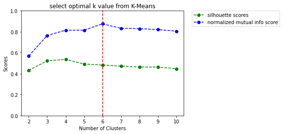

```
Optimal K value for this dataset(K-Means): 6
```

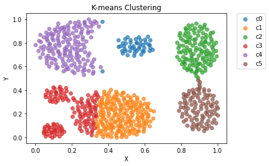

```
DBSCAN==========================================================
```

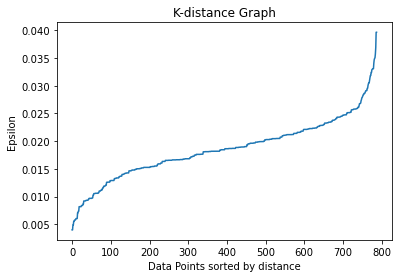

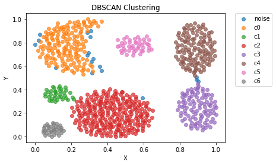

```
Expectation Maximization========================================
```

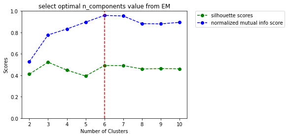

```
Optimal n_components value for this dataset(EM): 6
```

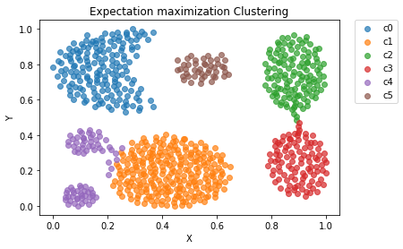

```
Agglomerative Clustering=====================================================
```

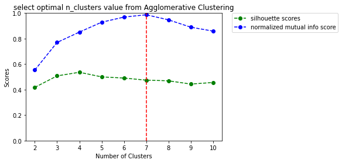

```
Optimal n_clusters value for this dataset(Agglomerative Clustering): 7
```

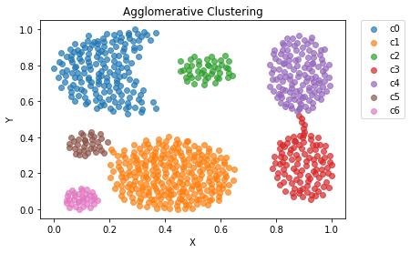

```python
#using sklearn.metrics compare all the algorithm results
#Dataset-1 ------------------------------------------------------------------------------------------------------------------

#k-means
print("Dataset-1=========================================================")
print("K-means===========================================================")
km_score_df1 = k_means(df=df1)

#DBSCAN
print("\nDBSCAN==========================================================")
dbscan_score_df1 = db_scan(eps=0.036,
                           min_samples=5,
                           df=df1)

#expectation maximization
print("\nExpectation Maximization========================================")
em_score_df1 = expectation_maximization(covariance_type='full',
                                        n_init=10,
                                        init_params='kmeans',
                                        df=df1)

#AgglomerativeClustering
print("\nAgglomerative Clustering=====================================================")
al_score_df1 = agglomerative_clustering(linkage="average",
                                        df=df1)
```

```python
#Dataset-1 scores
print("Scores for Dataset-1:")
score_list_df1 = [km_score_df1, dbscan_score_df1, em_score_df1, al_score_df1]

#Create the pandas DataFrame
scores_df1 = pd.DataFrame(score_list_df1, columns = ['Silhouette score', 'Normalized mutual info score', 'Algorithm'])

#find max score algorithm's name and append it in last row
best = scores_df1["Algorithm"].iloc[scores_df1['Normalized mutual info score'].idxmax()]
scores_df1.loc[len(scores_df1.index)] = ['Best clustering algorithm', "------->", best]
scores_df1
# print("Best clustering algorithm for dataset-1: {}".format(scores_df1["Algorithm"].iloc[scores_df1['Normalized mutual info score'].idxmax()]))
```

```
Scores for Dataset-1:
```

|  | Silhouette score | Normalized mutual info score | Algorithm |
| --- | --- | --- | --- |
| 0 | 0.481407 | 0.874362 | k-means |
| 1 | 0.458522 | 0.963196 | DBSCAN |
| 2 | 0.490804 | 0.95433 | Expectation maximization |
| 3 | 0.474198 | 0.986939 | Agglomerative Clustering |
| 4 | Best clustering algorithm | -------> | Agglomerative Clustering |

```
Dataset-2=========================================================
K-means===========================================================
```

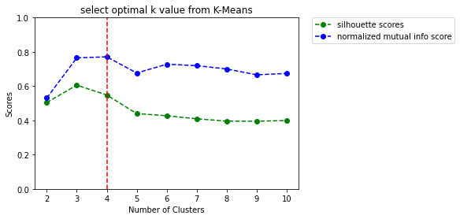

```
Optimal K value for this dataset(K-Means): 4
```

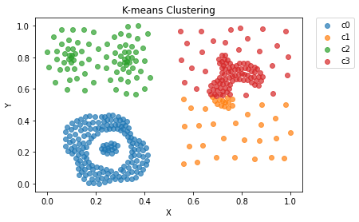

```
DBSCAN==========================================================
```

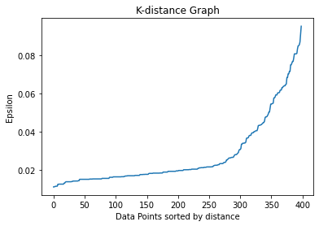

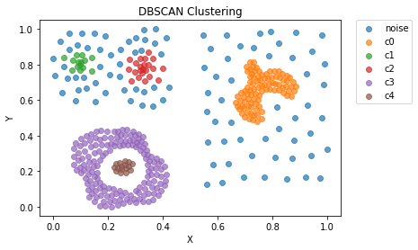

```
Expectation Maximization========================================
```

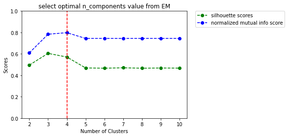

```
Optimal n_components value for this dataset(EM): 4
```

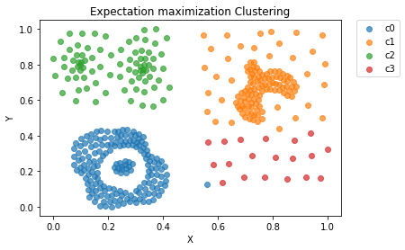

```
Agglomerative Clustering=====================================================
```

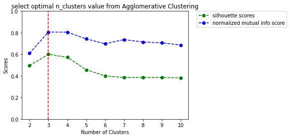

```
Optimal n_clusters value for this dataset(Agglomerative Clustering): 3
```

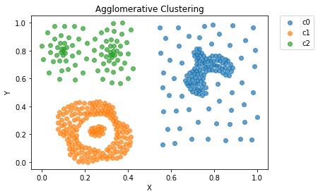

```python
#Dataset-2 ---------------------------------------------------------------------------------------------------------------------
#k-means
print("Dataset-2=========================================================")
print("K-means===========================================================")
km_score_df2 = k_means(df=df2)

#DBSCAN
print("\nDBSCAN==========================================================")
dbscan_score_df2 = db_scan(eps=0.04,
                           min_samples=5,
                           df=df2)

#expectation maximization
print("\nExpectation Maximization========================================")
em_score_df2 = expectation_maximization(covariance_type='spherical',
                                        n_init=10,
                                        init_params='kmeans',
                                        df=df2)

#AgglomerativeClustering
print("\nAgglomerative Clustering=====================================================")
al_score_df2 = agglomerative_clustering(linkage="ward",
                                        df=df2)
```